# Time series classification and clustering in R

Peter Laurinec

October 23, 2017

Load all needed packages.

```r
library(data.table) # data handling
library(ggplot2) # visualizations
library(randomForest) # for classification
library(cluster) # for clustering
library(clv) # cluster validation
```

Read the time series data. Train and Test part.

```r
ts_data_train <- fread("ItalyPowerDemand\\ItalyPowerDemand_TRAIN")
ts_data_test <- fread("ItalyPowerDemand\\ItalyPowerDemand_Test")
```

Chceck structure of our data.

```r
str(ts_data_train)
```

```
## Classes 'data.table' and 'data.frame':   67 obs. of  25 variables:
##  $ V1 : int  1 1 2 2 1 1 2 1 1 2 ...
##  $ V2 : num  -0.711 -0.993 1.319 -0.812 -0.973 ...
##  $ V3 : num  -1.18 -1.43 0.57 -1.16 -1.39 ...
##  $ V4 : num  -1.372 -1.58 0.195 -1.416 -1.537 ...
##  $ V5 : num  -1.5931 -1.6054 -0.0859 -1.5314 -1.6202 ...
##  $ V6 : num  -1.47 -1.63 -0.18 -1.5 -1.62 ...
##  $ V7 : num  -1.372 -1.376 -0.273 -1.416 -1.453 ...
##  $ V8 : num  -1.0888 -1.0185 -0.0859 -1.6465 -0.9937 ...
##  $ V9 : num  0.046 -0.3551 -1.3971 -0.4673 0.0505 ...
##  $ V10: num  0.929 0.717 -1.116 0.654 0.635 ...
##  $ V11: num  1.086 1.201 -0.741 1.057 1.032 ...
##  $ V12: num  1.2753 1.1248 0.00781 1.3445 0.80229 ...
##  $ V13: num  0.96 1.0483 -0.0859 1.2007 0.8232 ...
##  $ V14: num  0.61333 0.79313 0.00781 0.99938 0.6561 ...
##  $ V15: num  0.0144 0.4614 -0.4605 0.6543 0.3846 ...
##  $ V16: num  -0.647 0.487 -0.554 0.741 0.322 ...
##  $ V17: num  -0.269 0.563 -0.741 0.884 0.489 ...
##  $ V18: num  -0.206 0.615 -0.741 0.884 0.614 ...
##  $ V19: num  0.613 0.308 -0.741 0.683 1.304 ...
##  $ V20: num  1.37 0.257 -1.116 0.626 1.241 ...
##  $ V21: num  1.464 1.099 -0.461 0.424 1.074 ...
##  $ V22: num  1.0546 1.0483 0.47611 -0.00719 0.55168 ...
##  $ V23: num  0.5818 0.6911 2.3493 -0.0359 0.4264 ...
##  $ V24: num  0.1721 -0.0489 2.2557 0.1079 -0.1792 ...
##  $ V25: num  -0.269 -0.381 1.6 -0.266 -0.639 ...
##  - attr(*, ".internal.selfref")=<externalptr>
```

```r
str(ts_data_test)
```

```
## Classes 'data.table' and 'data.frame':   1029 obs. of  25 variables:
##  $ V1 : int  2 2 2 2 2 1 2 2 2 2 ...
##  $ V2 : num  0.473 -1.099 -1.029 0.291 -0.815 ...
##  $ V3 : num  -0.396 -1.135 -1.24 -0.324 -1.271 ...
##  $ V4 : num  -0.722 -1.6 -1.345 -0.883 -1.567 ...
##  $ V5 : num  -1.16 -1.71 -1.56 -1.11 -1.62 ...
##  $ V6 : num  -1.21 -1.64 -1.48 -1.27 -1.65 ...
##  $ V7 : num  -1.048 -1.457 -1.345 -0.659 -1.405 ...
##  $ V8 : num  -0.776 -1.027 -1.451 -0.883 -1.029 ...
##  $ V9 : num  -1.319 -0.705 -0.766 -0.492 -0.465 ...
##  $ V10: num  -0.831 0.478 0.261 -1.163 0.797 ...
##  $ V11: num  0.256 1.23 0.972 -0.324 1.414 ...
##  $ V12: num  0.962 1.266 1.13 0.571 1.307 ...
##  $ V13: num  1.125 1.123 1.183 0.627 1.334 ...
##  $ V14: num  0.582 0.764 0.762 0.627 1.092 ...
##  $ V15: num  0.201 0.657 0.893 -0.1 0.555 ...
##  $ V16: num  -0.233 0.514 0.893 -0.324 0.689 ...
##  $ V17: num  -0.342 0.621 1.078 -0.324 0.555 ...
##  $ V18: num  -0.668 0.729 1.104 -0.659 0.528 ...
##  $ V19: num  -0.722 0.37 0.788 -0.548 0.26 ...
##  $ V20: num  -0.45 0.406 0.63 -0.548 0.125 ...
##  $ V21: num  -0.0158 0.3702 0.3666 0.4031 0.2059 ...
##  $ V22: num  0.7988 0.0836 0.0505 2.3605 0.2327 ...
##  $ V23: num  2.2653 1.0151 -0.0549 2.0249 0.7967 ...
##  $ V24: num  1.939 0.621 0.261 1.801 0.26 ...
##  $ V25: num  1.288 0.119 -0.108 0.906 -0.331 ...
##  - attr(*, ".internal.selfref")=<externalptr>
```

Check classes:

```r
table(ts_data_train$V1)
```

```
##
##  1  2
## 34 33
```

```r
table(ts_data_test$V1)
```

```
##
##   1   2
## 513 516
```

Create data object.

```r
class_train <- unlist(ts_data_train[, 1, with = F])
data_train <- ts_data_train[, -1, with = F]
class_test <- unlist(ts_data_test[, 1, with = F])
data_test <- ts_data_test[, -1, with = F]
```

Visualize the train data.

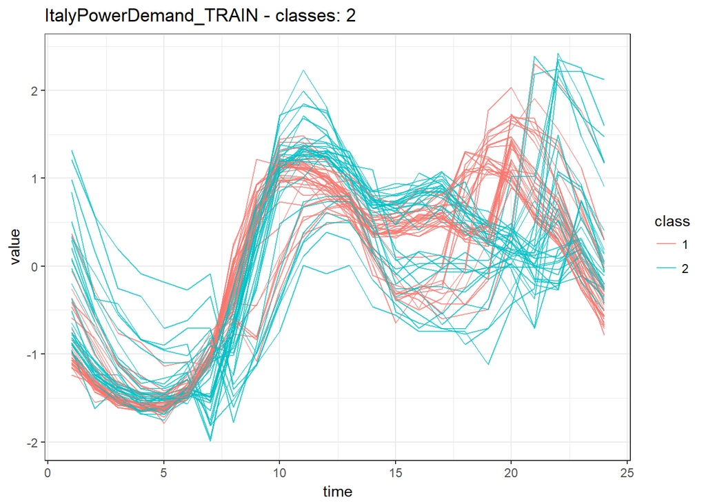

```r
datas <- data.table(melt(data_train))
datas[, time := rep(1:ncol(data_train), each = nrow(data_train))]
datas[, class := as.factor(rep(class_train, ncol(data_train)))]
datas[, id := rep(1:nrow(data_train), ncol(data_train))]

ggplot(datas, aes(time, value, group = id, color = class)) +
  geom_line(alpha = 0.75) +
  labs(title = paste("ItalyPowerDemand", "_TRAIN", " - classes: ", length(unique(class_train)), sep = "")) +
  theme_bw()
```

Visualize the test data.

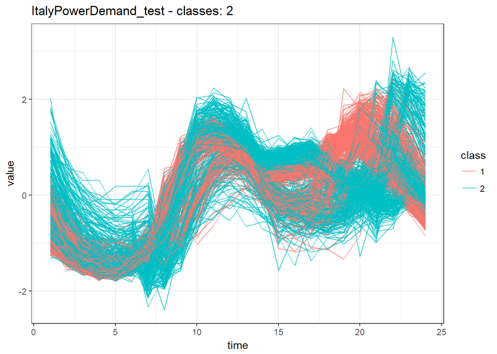

```r
datas <- data.table(melt(data_test))
datas[, time := rep(1:ncol(data_test), each = nrow(data_test))]
datas[, class := as.factor(rep(class_test, ncol(data_test)))]
datas[, id := rep(1:nrow(data_test), ncol(data_test))]

ggplot(datas, aes(time, value, group = id, color = class)) +
  geom_line(alpha = 0.75) +
  labs(title = paste("ItalyPowerDemand", "_test", " - classes: ", length(unique(class_test)), sep = "")) +
  theme_bw()
```

## Classification of time series with Random Forest

Let’s try to train classification model. We will use all the data as it is to training.

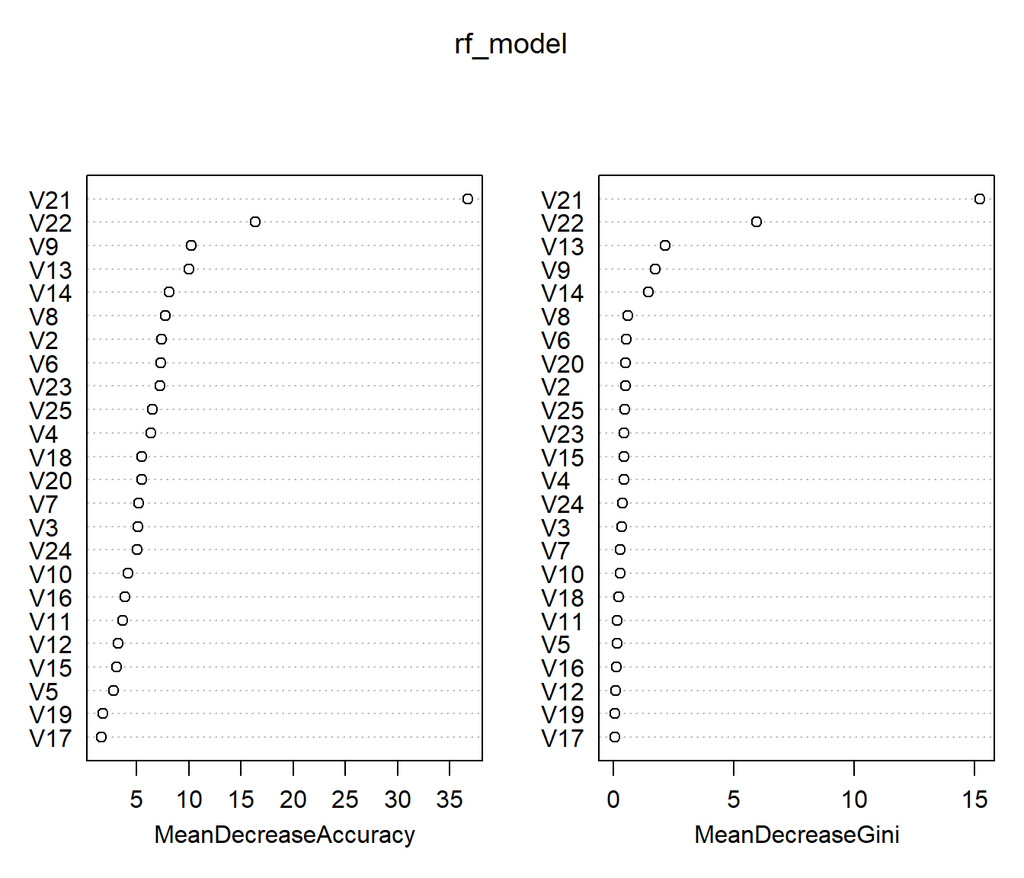

```r
ts_data_train[, V1 := as.factor(V1)] # change V1 to character or factor to do classification

rf_model <- randomForest(V1 ~ ., data = data.frame(ts_data_train),
                         ntree = 1000, mtry = 12, nodesize = 5, importance = TRUE)

varImpPlot(rf_model)
```

Accuracy on training data.

```r
pred_train <- predict(rf_model, data.frame(data_train))

# Confusion matrix:
table(class_train, pred_train)
```

```
##            pred_train
## class_train  1  2
##           1 33  1
##           2  0 33
```

Just one misclassification on training data.

Now make predictions on testing data.

```r
pred_test <- predict(rf_model, data.frame(data_test))

# Confusion matrix:
table(class_test, pred_test)
```

```
##           pred_test
## class_test   1   2
##          1 496  17
##          2  14 502
```

Pretty accurate.

Let’s visualaze the results:

```r
datas <- data.table(melt(data_test))
```

[figure not shown]

```r
datas[, time := rep(1:ncol(data_test), each = nrow(data_test))]
datas[, class := as.factor(rep(pred_test, ncol(data_test)))]
datas[, id := rep(1:nrow(data_test), ncol(data_test))]

ggplot(datas, aes(time, value, group = id, color = class)) +
  geom_line(alpha = 0.75) +
  labs(title = paste("ItalyPowerDemand", "_test; Predictions;", " - classes: ", length(unique(pred_test)), sep = "")) +
  theme_bw()
```

Not many visible differences compared to the TEST set.

Evaluation of results (accuracy):

```r
cm <- as.matrix(table(class_test, pred_test))

c(Accuracy = sum(diag(cm)) / sum(cm))
```

```
##  Accuracy
## 0.9698737
```

## Clustering of time series with K-medoids (PAM)

Let’s cluster it:

```r
res_pam <- pam(data_train, 2)
```

We can check the results.

```r
table(res_pam$clustering)
```

```
##
##  1  2
## 58  9
```

Fuuu. Very bad :))

Visualize the results.

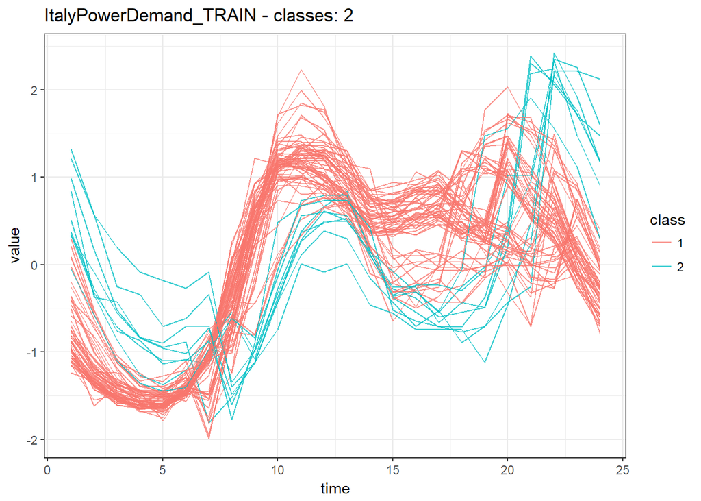

```r
datas <- data.table(melt(data_train))
datas[, time := rep(1:ncol(data_train), each = nrow(data_train))]
datas[, class := as.factor(rep(res_pam$clustering, ncol(data_train)))]
datas[, id := rep(1:nrow(data_train), ncol(data_train))]

ggplot(datas, aes(time, value, group = id, color = class)) +
  geom_line(alpha = 0.75) +
  labs(title = paste("ItalyPowerDemand", "_TRAIN", " - classes: ", length(unique(res_pam$clustering)), sep = "")) +
  theme_bw()
```

There is some good signigs, but…

How to classify TEST data to nearest clusters? We will use Euclidean distance and stored medoids (in `res_pam`) to classify time series to nearest medoids.

```r
my_knn <- function(data, query) {
  as.integer(which.min(as.matrix(dist(rbind(data, query)))[nrow(data)+1,-(nrow(data)+1)]))
}

pred_test_pam <- sapply(seq_along(class_test),
                    function(z) my_knn(res_pam$medoids, as.numeric(data_test[z,])))
```

Check the results:

```r
table(pred_test_pam)
```

```
## pred_test_pam
##   1   2
## 881 148
```

Evaluate the results with external validation indexes.

```r
c(RandIndex = clv.Rand(std.ext(class_test, as.integer(pred_test_pam))))
```

```
## RandIndex
## 0.5029287
```

```r
c(Folkes.Mallows = clv.Folkes.Mallows(std.ext(class_test, as.integer(pred_test_pam))))
```

```
## Folkes.Mallows
##        0.61608
```

Almost like a random guess.

And finally let’s visualaze the results:

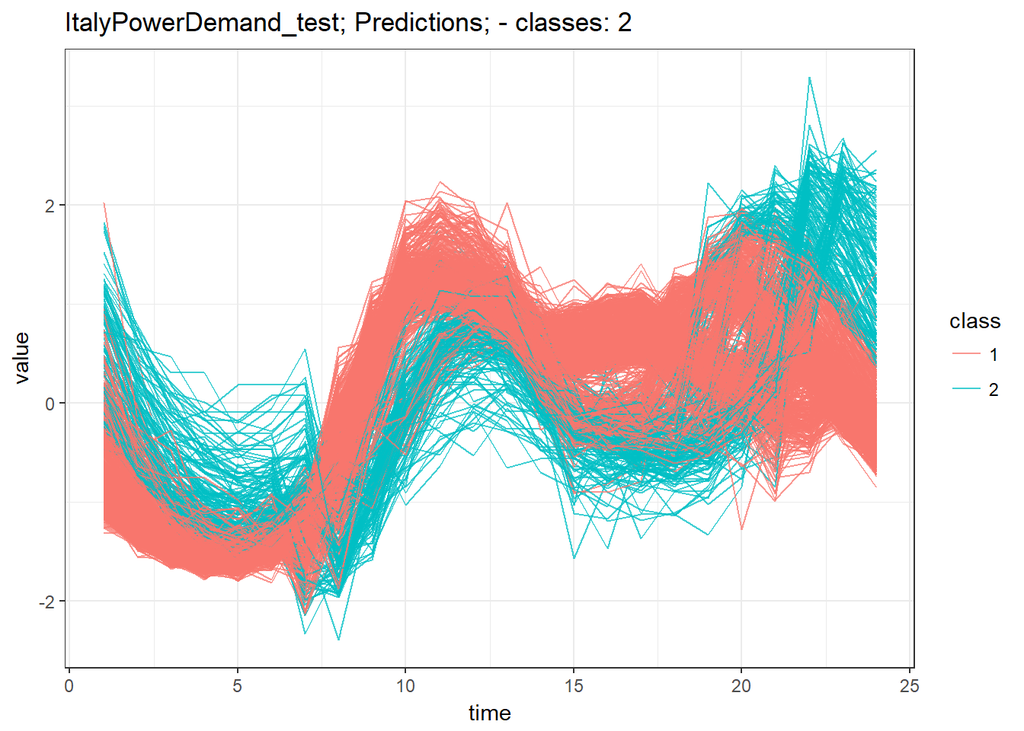

```r
datas <- data.table(melt(data_test))
datas[, time := rep(1:ncol(data_test), each = nrow(data_test))]
datas[, class := as.factor(rep(pred_test_pam, ncol(data_test)))]
datas[, id := rep(1:nrow(data_test), ncol(data_test))]

ggplot(datas, aes(time, value, group = id, color = class)) +
  geom_line(alpha = 0.75) +
  labs(title = paste("ItalyPowerDemand", "_test; Predictions;", " - classes: ", length(unique(pred_test_pam)), sep = "")) +
  theme_bw()
```

Possible solution is to try transform the data. Let’s try PCA.

```r
pca_train <- prcomp(data_train, center = T, scale. = T)
```

```r
pca_test <- predict(pca_train, data_test)[,1:3]
pca_train <- pca_train$x[,1:3]
```

Visualize what I did.

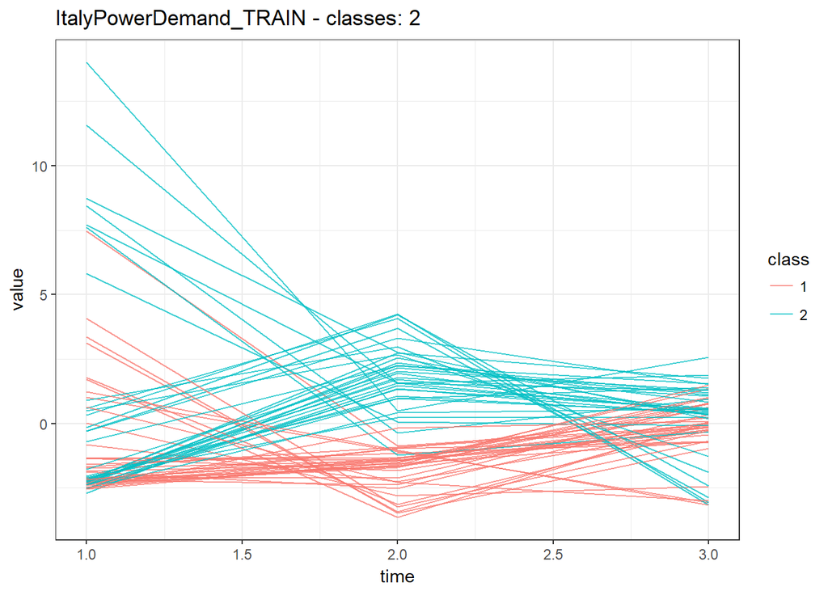

```r
datas <- data.table(melt(pca_train))
datas[, time := rep(1:ncol(pca_train), each = nrow(pca_train))]
datas[, class := as.factor(rep(class_train, ncol(pca_train)))]
datas[, id := rep(1:nrow(pca_train), ncol(pca_train))]

ggplot(datas, aes(time, value, group = id, color = class)) +
  geom_line(alpha = 0.75) +
  labs(title = paste("ItalyPowerDemand", "_TRAIN", " - classes: ", length(unique(class_train)), sep = "")) +
  theme_bw()
```

```r
res_pam_pca <- pam(pca_train[,2], 2)
```

We can check the results.

```r
table(res_pam_pca$clustering)
```

```
##
##  1  2
## 38 29
```

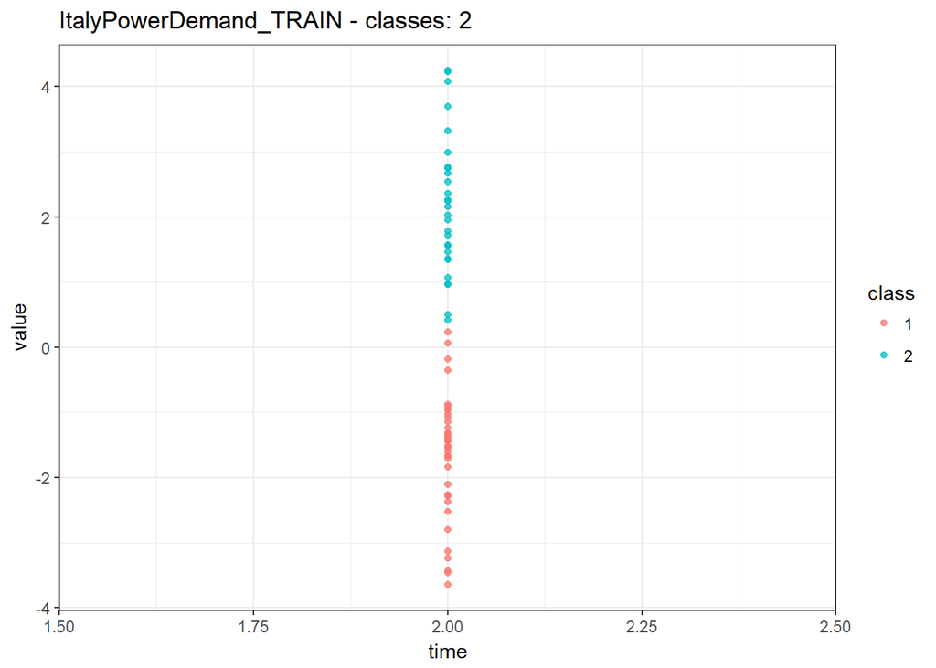

```r
datas <- data.table(value = pca_train[,2])
datas[, time := 2]
datas[, class := as.factor(res_pam_pca$clustering)]

ggplot(datas, aes(time, value, color = class)) +
  geom_point(alpha = 0.75) +
  labs(title = paste("ItalyPowerDemand", "_TRAIN", " - classes: ", length(unique(class_train)), sep = "")) +
  theme_bw()
```

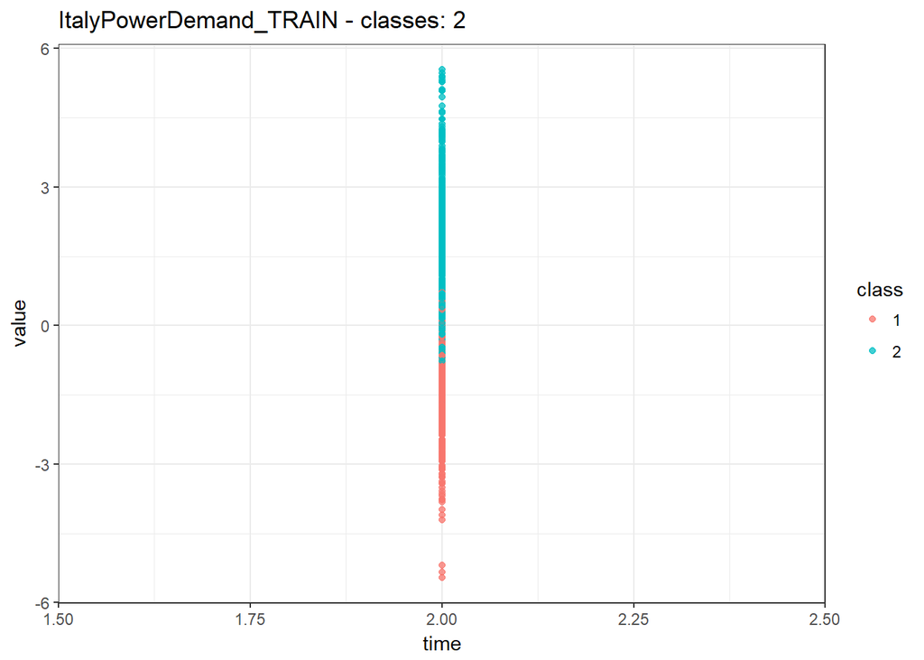

```r
datas <- data.table(value = pca_test[,2])
datas[, time := 2]
datas[, class := as.factor(class_test)]

ggplot(datas, aes(time, value, color = class)) +
  geom_point(alpha = 0.75) +
  labs(title = paste("ItalyPowerDemand", "_TRAIN", " - classes: ", length(unique(class_train)), sep = "")) +
  theme_bw()
```

```r
pred_test_pam_pca <- sapply(seq_along(class_test),
                    function(z) my_knn(res_pam_pca$medoids, as.numeric(pca_test[z,2])))
```

Check the results:

```r
table(pred_test_pam_pca)
```

```
## pred_test_pam_pca
##   1   2
## 564 465
```

Evaluate the results with external validation indexes.

```r
c(RandIndex = clv.Rand(std.ext(class_test, as.integer(pred_test_pam_pca))))
```

```
## RandIndex
## 0.8781371
```

```r
c(Folkes.Mallows = clv.Folkes.Mallows(std.ext(class_test, as.integer(pred_test_pam_pca))))
```

```
## Folkes.Mallows
##      0.8785914
```

And finally let’s visualaze the results:

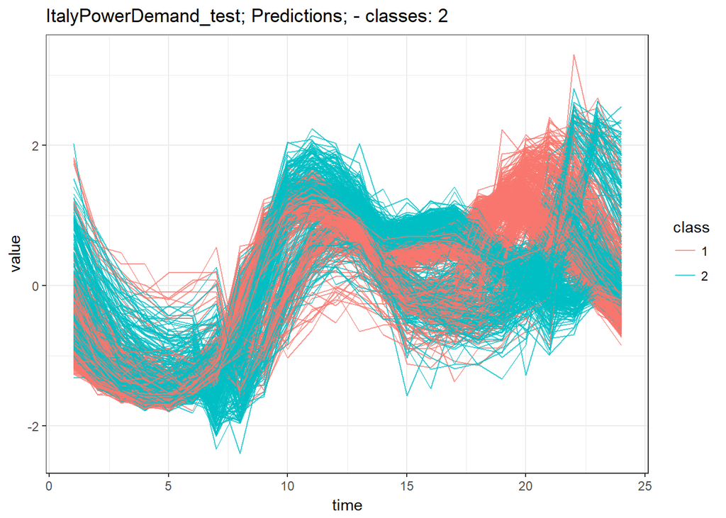

```r
datas <- data.table(melt(data_test))
datas[, time := rep(1:ncol(data_test), each = nrow(data_test))]
datas[, class := as.factor(rep(pred_test_pam_pca, ncol(data_test)))]
datas[, id := rep(1:nrow(data_test), ncol(data_test))]

ggplot(datas, aes(time, value, group = id, color = class)) +
  geom_line(alpha = 0.75) +
  labs(title = paste("ItalyPowerDemand", "_test; Predictions;", " - classes: ", length(unique(pred_test_pam_pca)), sep = "")) +
  theme_bw()
```